# Hypothesis testing basics

```r
set.seed(431234462)
```

# Why would we want to run experiments?

Running experiments can help us with learning about our users. We learn how users react to changes we make and we refer back to those learnings when designing new features or improving current ones.

Running experiments also helps us produce value more efficiently. Similarly to companies like Spotify and Netflix it allows us to gather feedback on rough ideas and iterate. Wouldn’t it be better to have some feedback before allocating tens of engineers for months just to release a feature that might not be enjoyed by our users?

Now, let’s test all the things!

Not so fast though, proper set up and analysis is required to get value from experimentation. If we mess up the experiment design or math, experimentation can cause more harm than good. We’ll talk about some pitfalls in another doc. Here we have a look at the underlying math.

In our case we might be interested in how a change to the ‘sell’ button affects our users. There are probably tons of things we want to know, i.e. metrics.

Will users click the button more?

Will users list more?

Just looking at the two here, which one do we prefer? Maybe ‘will users list more?’ is more in line with our business goal.

# How do we analyse experiments?

To analyse experiments we run frequentist hypothesis tests. They are widely used and well documented. We split our users in two groups and compare them to see whether there is a difference or not.

A hypothesis consists of two hypotheses $H_0$ and $H_a$.

- $H_0: \mu_1 = \mu_2$ – There is no difference between the groups
- $H_a: \mu_2 \neq \mu_2$ – There is a difference between the groups

For the test to be of value it needs to be ‘powered’, to be sure the change we detect is not caused by chance.

# Power Analysis

So, how do we ‘power’ a test and what is ‘power’ actually? Power is how likely we are to detect a change given there really is a change.

Closely related is the significance level, which often is set at 95%, which is how likely we are to detect no change when there really is no change. What is the remaining 5% here? That is how likely we are to detect a change when there actually is none, i.e. a false positive.

In total we have 4 possibilities. Rows reflect the reality and columns the test result.

```r
possibilities <- data.frame(NoChange=c("True negative", "False negative"), Change=c("False positive", "True positive"), row.names = c("NoChange", "Change"))
possibilities
```

|  | NoChange | Change |
| --- | --- | --- |
| NoChange | True negative | False positive |
| Change | False negative | True positive |

Power depends on

- the significance level
- the sample size, i.e. the number of users we assign to each group
- the effect size, i.e. the size of the change we want to be able to detect

Some definitions:

- $\alpha$: the probability of a false positive
- significance level: the probability of a true negative; 1 - $\alpha$
- $\beta$: the probability of a false negative
- power: the probability of a true positive; 1 - $\beta$

# Hypothesis testing

Suppose we want to know whether the average height of men is different from the average height of women. We can test this using a t-test. There are different kinds of tests, e.g. z-test, but for most of our use cases the t-test will be appropriate.

All tests have some assumptions about the underlying data.

1. Data needs to be i.i.d., i.e. independent and identically distributed.
2. The data needs to be normally distributed.

1. we can solve by random sampling. Here we would randomly sample $N$ men from the population of all men and $N$ women from the population of all women. Random sampling gives us independent samples, but the explanation is out of scope here. Both times we measure heights which come from the same kind of distribution, which gives us the identically distributed property.

2. is a bit harder to explain. Obviously our data could have any other distribution than normal. If we would look at conversions for example, they often are distributed similarly to a Bernoulli distribution.

Luckily, the tests don’t use our samples directly (they are mosty likely not normal), but the sample means, which brings us to the most central theorem in statistics, the …

# Central Limit Theorem

Below are the histograms of a sample of male heights, female heights and sample from a population of both men and women. The latter being a bimodal distribution.

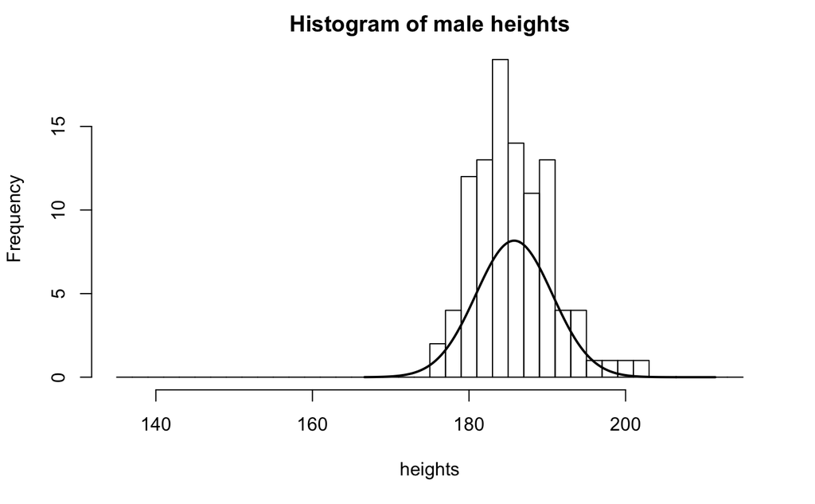

```r
sample_male_heights <- function(N, mean = 185) {
  rnorm(N, mean = mean, sd = 5)
}
sample_female_heights <- function(N) {
  rnorm(N, mean = 165, sd = 5)
}
sample_population <- function(N) {
  w = rbinom(N, 1, .5)
  w * sample_male_heights(N) + (1 - w) * sample_female_heights(N)
}
plot_heights <- function(heights, title) {
  hist(heights, breaks = seq(135,215,2), main = title)
  x.h1 <- seq(min(heights)-10, max(heights)+10, by = 0.2)
  y.h1 <- dnorm(x.h1, mean=mean(heights), sd=sd(heights)) * 100
  lines(x.h1, y = y.h1, lwd = 2)
}
male_heights <- sample_male_heights(100)
female_heights <- sample_female_heights(100)
heights <- sample_population(100)
plot_heights(male_heights, "Histogram of male heights")
```

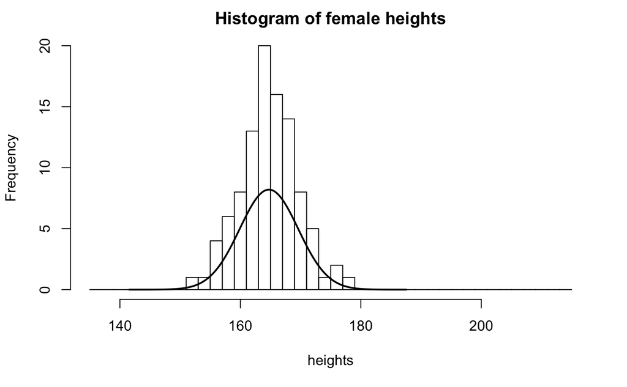

```r
plot_heights(female_heights, "Histogram of female heights")
```

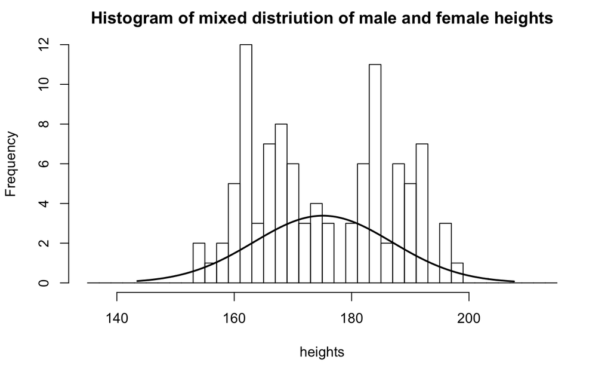

```r
plot_heights(heights, "Histogram of mixed distriution of male and female heights")
```

Obviously the mixed distribution is not normal distributed. So how do we arrive at a normal distribution if this is our population distribution?

The plots below show, 1 sample mean, 100 sample means of sample size 5, 100 sample means of sample size 100

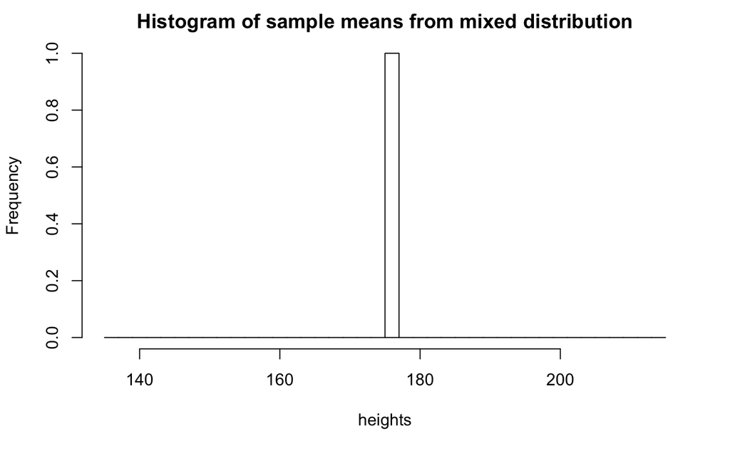

```r
heights_mean <- mean(heights)
plot_heights(heights_mean, "Histogram of sample means from mixed distribution")
```

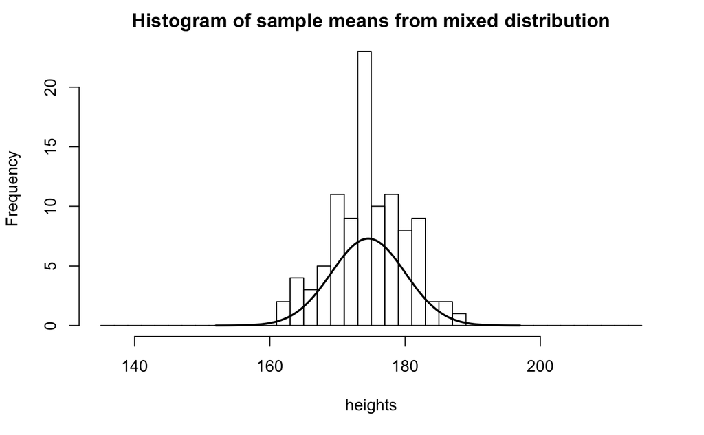

```r
library(data.table)
sampling_distribution <- function(N) {
  height_means = c()
  for (i in 1:100) {
    height_means <- append(height_means, mean(sample_population(N)))
  }
  height_means
}
small_N <- 5
means <- sampling_distribution(small_N)
plot_heights(means, "Histogram of sample means from mixed distribution")
```

```r
mean(means)
```

```
[1] 174.558
```

```r
var(means)
```

```
[1] 29.90467
```

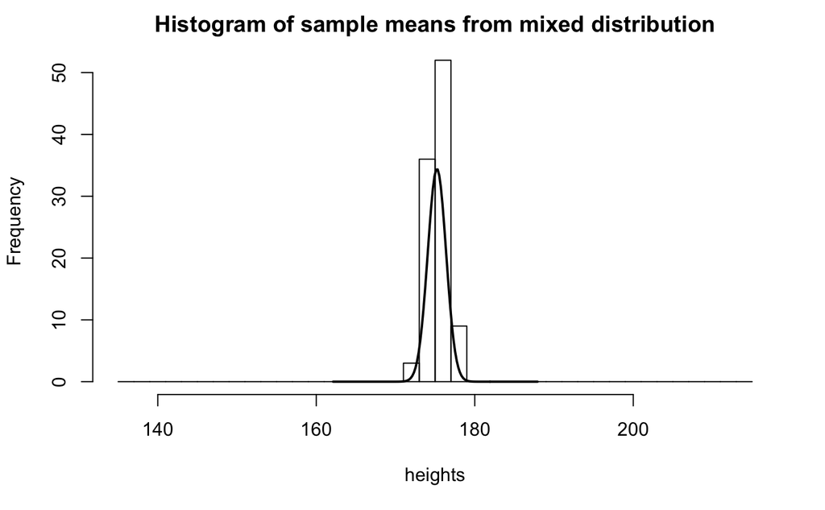

```r
large_N <- 100
means <- sampling_distribution(large_N)
plot_heights(means, "Histogram of sample means from mixed distribution")
```

```r
mean(means)
```

```
[1] 175.2296
```

```r
var(means)
```

```
[1] 1.34147
```

You can see that this approximates a normal distribution.

Maybe you noticed that the variance between the 5 sample and the 100 sample distribution is very different.  
This is why the CLT only works asymptotically.

With large $N$ the Law of Large Numbers kicks in. The LLN says that as $N$ goes to infinity the sample mean approximates the population mean.

If we took $N = 1$ then our sampling distribution would equal the population distribution.

It’s not easy to say how large $N$ needs to be that the sampling distribution becomes standard normal. This depends on how normal the population distribution is to begin with.

# Hypothesis testing II

So now that we know how to satisfy the 2 assumptions about the data let’s continue with the t-test.  
The t-test itself has another assumption, i.e. that the variances of the two samples are equal. Since we control this and we set the SD for both to be 5, this is satisfied.

We start by defining our hypotheses

- $H_0: \mu_m = \mu_f$ – Men and women heights are the same
- $H_a: \mu_m \neq \mu_f$ – Men and women heights are different

The t-statistic, $t$, for this is

$$s_m^2 = \frac{\sum{(X_{mi}-\overline{X})}^2}{n_m-1}$$
Where $n_m$ is the number of samples from the male population.

$s_f^2$ is calculated similarly

$$SE_{pooled} = \frac{(n_m - 1) s_m^2 + (n_f - 1) s_f^2}{(n_m + n_f - 2)}$$
$$t = \frac{(\mu_m - \mu_f)}{(SE_{pooled} * \sqrt{1 / n_m + 1 / n_f}}$$

Where $SE_{pooled}$ is the pooled variance, which is a weighted average of the two variances. The more samples we have, i.e. correcter the variance, the more it should be weighted.

Why this works exactly is, again, out of the scope here, but what it means is:  
How likely is our sampling distribution to be the same as our $H_0$ distribution which is a normal with mean 0 (because if $\mu_m = \mu_f \implies \mu_m - \mu_f = 0$)

Before we do the actual test we need to decide our parameters, i.e. $\alpha$ and $\beta$.

With the context built up so far let’s go back to power analysis and visualize $\alpha$, $\beta$, etc.

# Power Analysis II

The red lines are at the 2.5% and 97.5% percentile. Summing this gives 5%, which is our $\alpha$

Given our $H_0$ is true:  
If the test statistic is inside the bars we accept our $H_0$, there is not enough evidence to reject $H_0$, e.g. true negative.  
If the test statistic is outside the bars we reject our $H_0$ and the result is a false positive.

Similarly the red areas are the probability density of a false positive.

Given $H_a$ is true:  
The orange area shows beta. If our test statistic is in this region we don’t reject $H_0$ resulting in a false negative.  
The green area shows power, i.e. $1-beta$. If our test statistic is in this region we reject $H_0$ resulting in a true positive.

```r
z.statistics <- function(a, b, alpha = 0.05) {
  # checked against z.test, if population variance is used instead of sample variance they match
  N.a <- length(a)
  N.b <- length(b)
  SE.a <- sd(a) / sqrt(N.a)
  SE.b <- sd(b) / sqrt(N.b)
  SE <- sqrt(SE.a^2 + SE.b^2)
  delta <- mean(a) - mean(b)
  z <- (delta) / SE
  p <- 2*pnorm(z, mean = 0, sd = 1, lower.tail = FALSE)
  interval <- c(delta - qnorm(p = 1 - alpha / 2) * SE, delta + qnorm(p = 1 - alpha / 2) * SE)
  list(sd = SE, mean = delta, z = z, p = p, interval = interval)
}

plot.power <- function(male_heights, female_heights, significance.level = 0.95, sd = 1, delta = 0, draw.z = FALSE) {
  z.stats <- z.statistics(male_heights, female_heights)
  mean.h0 <- 0
  sd.h0 <- z.stats$sd
  mean.h1 <- z.stats$mean
  sd.h1 <- z.stats$sd

  limit.lower <- min(-5, qnorm(p = 0.001, mean = mean.h0, sd = sd.h1))
  limit.upper <- max(10, qnorm(p = 0.9999, mean = mean.h1, sd = sd.h1))

  x.h0 <- seq(limit.lower, limit.upper, by = 0.1)
  y.h0 <- dnorm(x.h0, mean=mean.h0, sd=sd.h0)
  plot(x.h0, y.h0, type = "l", lwd = 2, xlim = c(limit.lower, limit.upper), xaxs = "i", yaxs = "i")

  x.h1 <- seq(limit.lower, limit.upper, by = 0.1)
  y.h1 <- dnorm(x.h1, mean=mean.h1, sd=sd.h1)
  lines(x.h1, y = y.h1, lwd = 2)

  # confidence regions
  alpha <- 1 - significance.level
  p95.start <- qnorm(p = alpha / 2, mean = mean.h0, sd = sd.h0)
  p95.end <- qnorm(p = 1 - alpha / 2, mean = mean.h0, sd = sd.h0)

  # power
  x.power.area <- seq(limit.lower, limit.upper, by = 0.1)
  y.power.area <- dnorm(x.power.area, mean = mean.h1, sd = sd.h1)
  polygon(cbind(c(min(x.power.area), x.power.area, max(x.power.area)), c(0, y.power.area, 0)), col="#00CC66", lwd = 2)

  # alpha
  x.alpha.area <- seq(p95.start - 10, p95.start, by = 0.1)
  y.alpha.area <- dnorm(x.alpha.area, mean = mean.h0, sd = sd.h0)
  polygon(cbind(c(min(x.alpha.area), x.alpha.area, max(x.alpha.area)), c(0, y.alpha.area, 0)), col="#CC0000", lwd = 2)

  x.alpha.area <- seq(p95.end, p95.end + 10, by = 0.1)
  y.alpha.area <- dnorm(x.alpha.area, mean = mean.h0, sd = sd.h0)
  polygon(cbind(c(min(x.alpha.area), x.alpha.area, max(x.alpha.area)), c(0, y.alpha.area, 0)), col="#CC0000", lwd = 2)

  # beta
  x.beta.area <- seq(p95.start, p95.end, by = 0.1)
  y.beta.area <- dnorm(x.beta.area, mean = mean.h1, sd = sd.h1)
  polygon(cbind(c(min(x.beta.area), x.beta.area, max(x.beta.area)), c(0, y.beta.area, 0)), col="#FFAA00", lwd = 2)

  # alpha lines
  abline(v = p95.start, col="#CC0000", lw = 3)
  abline(v = p95.end, col="#CC0000", lw = 3)

  # mean line
  abline(v = mean.h1, lw = 2, lty = "dashed")

  # z-test line
  if (draw.z) {
    abline(v = z.stats$z, lw = 2)
  }
}
```

```r
# to make the visualization easier to understand, let's assume heights are more similar
male_heights <- sample_male_heights(5, mean = 170)
female_heights <- sample_female_heights(5)
plot.power(male_heights, female_heights)
```

[output not shown]

Above we said that power, i.e. the green area, depends on

- the significance level
- the sample size, i.e. the number of users we assign to each group
- the size of the change we want to be able to detect

```r
plot.power(male_heights, female_heights, significance.level = 0.99)
```

[output not shown]

```r
plot.power(sample_male_heights(20, mean = 170) , sample_female_heights(20))
```

[output not shown]

```r
plot.power(sample_male_heights(20, mean = 175), sample_female_heights(20))
```

[output not shown]

Hopefully the plots could illustrate the different ways power changes related to the variables.

# Making sure we have enough power

We are almost ready to run the test. Now that we understood power let’s compute the number of users we need to have 80% power at a 95% significance level. Well used values in science.

Actually, we could aim for higher power because online experiments afford us with many more users than normal science experiments.

The formula is
$$N = 2 * (Z_{1-\frac{\alpha}{2}} + Z_\beta)^2 * (\frac{\sigma}{delta})^2$$
Where delta is the expected change. In our case let’s say we want to detect a 5cm difference.

```r
expected_change <- 5
sd <- 5 # this is specified in our sampling function
alpha <- 0.05
beta <- 0.2
z.alpha <- qnorm(p = 1 - alpha/2, lower.tail = TRUE)
z.beta <- qnorm(p = 1 - beta, lower.tail = TRUE)
N = ceiling(2*(z.alpha + z.beta)^2 * (sd / expected_change)^2)
sprintf("We need about %d samples", N)
```

[output not shown]

# t-test

Now that we have all the pre-requisites out of the way we can talk about the actual hypothesis test.  
Is there enough evidence of men being taller than women in our data that we can reject $H_0$? The t-test will answer this question.

```r
heights.male <- sample_male_heights(N, mean = 175)
heights.female <- sample_female_heights(N)
plot.power(heights.male, heights.female, draw.z = TRUE)

## note: t value is correct, p value is correct, interval is reasonably close. tested against t.test
# compute the t-statistic with pooled variance
alpha = 0.05
SE.pooled <- sqrt(((N-1)*var(heights.male) + (N-1)*var(heights.female)) / (N+N-2))
delta <- mean(heights.male) - mean(heights.female)
t <- ((delta) - 0) / (SE.pooled * sqrt(1/N + 1/N))
p <- 2*pt(t, df=2*N-2, lower.tail = FALSE)
interval <- c(delta - qt(p = 1 - alpha, df = 2*N-2) * (SE.pooled * sqrt(1/N + 1/N)), delta + qt(p = 1 - alpha, df = 2*N-2) * (SE.pooled * sqrt(1/N + 1/N)))
```

[output not shown]

# Appendix

## Where does the sample size formula come from?

## What is the difference between a Z-test and a t-test

## Why does the sample variance use n-1 instead of n

# TODO

- p values
- confidence intervals — always show difference with experiment
- t-test assumptions, pooled variance
- difference t distribution / normal distribution
- multiple testing
- unit of randomization / unit of analysis / delta method
- why do we need to compute power beforehand?
- trigger analysis